# Intro to Time-Series

Applied Econometrics for Finance

2025-10-16

# Random process vs Time-Series

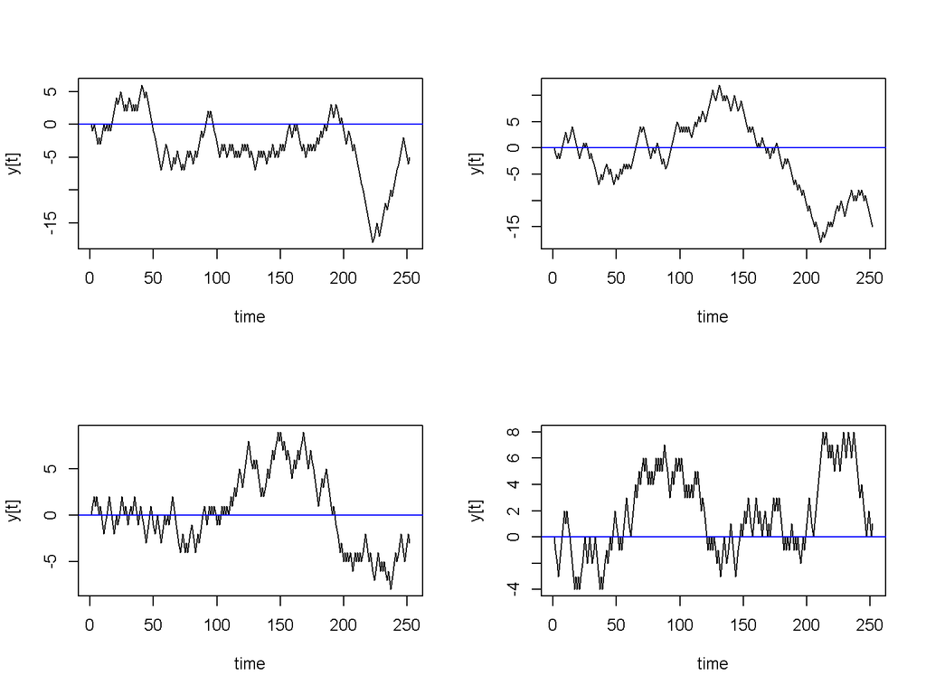

```r
nb.obs <- 252
nb.var <- 4
e <- replicate(n = nb.var,
expr = sample(c(-1, 1),
size = nb.obs, replace = TRUE,
prob = c(0.5, 0.5)))
y <- matrix(data = 0, nb.obs, nb.var)
for(i in 1:nb.var){
for(t in 2:nb.obs){
y[t, i] = y[t - 1, i] + e[t, i]
}
}
par(mfrow = c(2, 2))
for(i in 1:4){
plot(y[,i], type = "l", ylab = "y[t]", xlab = "time")
abline(h = 0, col = "blue")
}
```

# Autocorrelation functionsof time-Series

Proposition: The autocorrelation function of a time-series gives key insights about the properties of the underlying *data generating process*(i.e. random process)

Below, we generate time-series from three random processes and analyze their ACF’s :

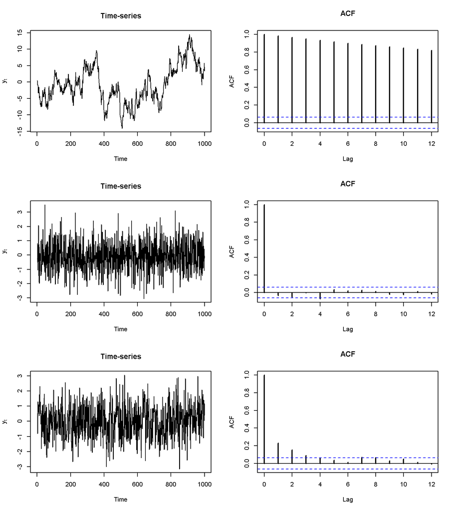

```r
# sample size
nb.obs <- 1000
# Generating time-series
y1 <- arima.sim(n = nb.obs,
list(order = c(1,0,0), ar = c(0.99)))
y2 <- arima.sim(n = nb.obs,
list(order = c(0,0,0)))
y3 <- arima.sim(n = nb.obs,
list(order = c(2,0,0), ar = c(0.25, 0.1)))
# visualize output
par(mfrow = c(3,2)) # 3 by 2 grid for ploy layout
plot.ts(y1, ylab = expression(y[t]), main = "Time-series")
acf(y1, lag.max =  12, lwd = 2, main = "ACF")
plot.ts(y2, ylab = expression(y[t]), main = "Time-series")
acf(y2, lag.max = 12, lwd = 2, main = "ACF")
plot.ts(y3, ylab = expression(y[t]), main = "Time-series")
acf(y3, lag.max = 12, lwd = 2, main = "ACF")
```

For example, the first 12 autocorrelations of the series $y2$ are :

```r
acf(y2, lag.max = 12, lwd = 2, main = "ACF", plot=FALSE)$acf
```

```
## , , 1
##
##               [,1]
##  [1,]  1.000000000
##  [2,] -0.033307795
##  [3,] -0.051436082
##  [4,] -0.003865179
##  [5,] -0.069178299
##  [6,]  0.032835920
##  [7,]  0.020116936
##  [8,]  0.026560889
##  [9,]  0.012894482
## [10,] -0.019722269
## [11,] -0.024087877
## [12,]  0.012258552
## [13,] -0.015293972
```

Observations

- The ACF of the series $y1$ is typical of that of a *non-stationary process* : The sample autocorrelations remain significant and persistent
- The ACF of the second and third series appear to belong to a *stationary process* with same significant serial correlation for $y3$.
- with $y2$, no significant serial correlation at lags 1, 2,…: current values *uncorrelated* with past values
- with *y3* , data appear to be stationary (horizental) but correlated with the past up to 2 lags. Q : How to exploit this dependence in a statistical model for $y3$?

# Testing autocorrelation

## Testing individual autocorrelation coefficients

```r
data <- read.csv(
          file.path(
            "https://raw.githubusercontent.com/erkind/",
            "AppEco/main/m-FF-funds-0518.csv"),
          header = TRUE, sep = ",")
```

```r
data_subset <- data[,c(2:4,18,19,20)]
dim(data_subset)
```

```
## [1] 165   6
```

```r
colnames(data_subset)
```

```
## [1] "MKT_RF" "SMB"    "HML"    "VFIAX"  "VSGIX"  "VSIIX"
```

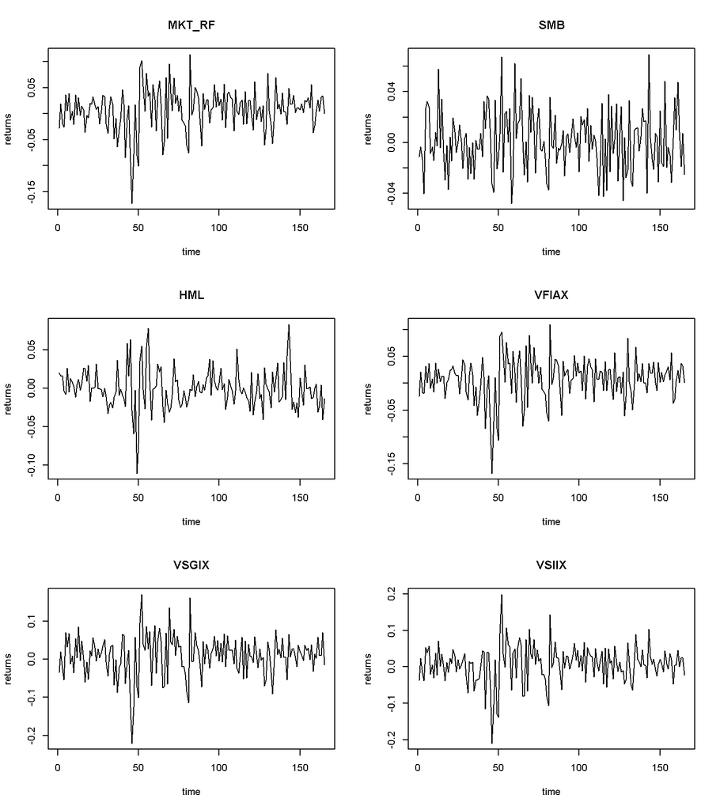

```r
par(mfrow = c(3,2))
for(i in 1:6){
  plot.ts(data_subset[,i], main = colnames(data_subset)[i],
          ylab = "returns", xlab = "time")
}
```

Observation: All the six time-series appear to be stationary; let’s check their sample ACF.

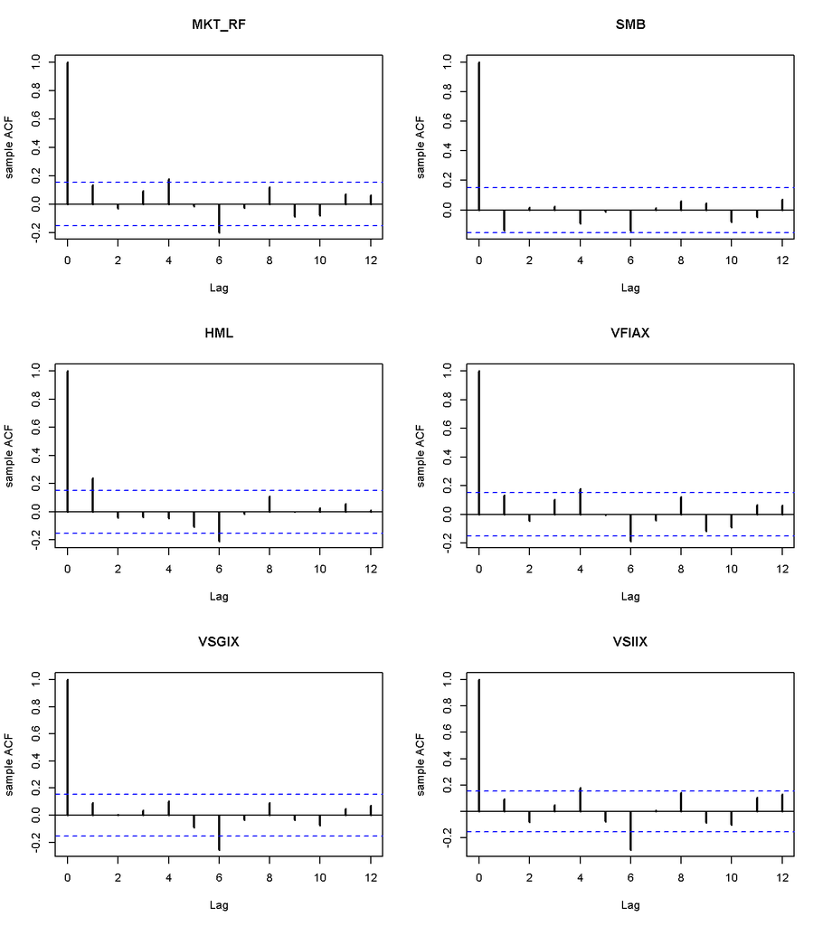

```r
par(mfrow = c(3,2))
for(i in 1:6){
  acf(data_subset[,i], main = colnames(data_subset)[i],
      lag.max = 12, type = c('correlation'), ylab = "sample ACF",
      plot = TRUE, lwd = 2)
}
```

*Exercice 1*: Extract the first 6 autocorrelations of the market risk premium. What is the value of lag-1 sample ACF? Using the large sample distribution of sample ACF, test if the lag-1 ACF is significantly different from 0.

```r
acf_test <- acf(data_subset[,1], lag.max = 6,
                type = c('correlation'), plot=FALSE)
```

Lag-1 sample ACF is

```r
acf_test$acf[2]
```

```
## [1] 0.1359636
```

The $t$-statistic is equal to ‘sample lag-1 ACF’ $\times$ ‘sqrt(sample size)’

```r
t_stat_rho1 <- acf_test$acf[2] * (length(data_subset$MKT_RF)^0.5)
t_stat_rho1
```

```
## [1] 1.746484
```

Decision : The critical values are the 0.5th and 99.5th percentiles of t-distribution at $T -1$ degrees-of-freedom. Using R (do it yourself using R function ‘qt()’), these values can be found as $-2.61$ and $2.61$. Thetest statistic lies outside the critical region, so $H_0$ cannot be rejected.

*Exercice 2*: Perform the same steps for testing lag-1 ACF of HML factor. Use 5% significance level to drive the critical values of the test. State your decision.

```r
t_stat_rho2 <- acf_test$acf[2] * (length(data_subset$HML)^0.5)
t_stat_rho2
```

[output not shown]

*Exercise 3* : Using the ‘Box.test()’ function, test the joint significance of the first 12 ACF’s of the returns on VSGIX and VSIIX. using the p-value of the output, state your decision at 5% significiance level.

```r
Box.test(data_subset$VSGIX, lag = 12, type = c('Ljung-Box'))
```

```
##
##  Box-Ljung test
##
## data:  data_subset$VSGIX
## X-squared = 20.508, df = 12, p-value = 0.05807
```

```r
Box.test(data_subset$VSIIX, lag = 12, type = c('Ljung-Box'))
```

```
##
##  Box-Ljung test
##
## data:  data_subset$VSIIX
## X-squared = 35.703, df = 12, p-value = 0.0003615
```